# An Introduction to Web Scraping

The purpose of web scraping is to extract data from web pages.

In this example, we will scrape the website [Books to Scrape](https://books.toscrape.com/index.html), a website designed for practicing basic scraping skills.

We will load the following libraries/modules:

- `requests`: This is for sending http requests to the website
- `bs4.BeautifulSoup`: This is a commonly used for parsing html (the format of most web pages) codes
- `pandas`: We will store the scraped data as a pandas DataFrame

```python
import requests
from bs4 import BeautifulSoup
```

Let's define the url and the headers.

HTTP headers are key-value pairs sent with HTTP requests and responses, providing additional information to the server or client. Headers are crucial in web scraping to make requests appear more like those from a browser and avoid being flagged as a bot.

```python
url = "https://books.toscrape.com/index.html"

headers = {'User-Agent': 'Mozilla/5.0 (Macintosh; Intel Mac OS X 10_15_7) AppleWebKit/537.36 (KHTML, like Gecko) Chrome/131.0.0.0 Safari/537.36 Edg/131.0.0.0'}
```

Common headers:

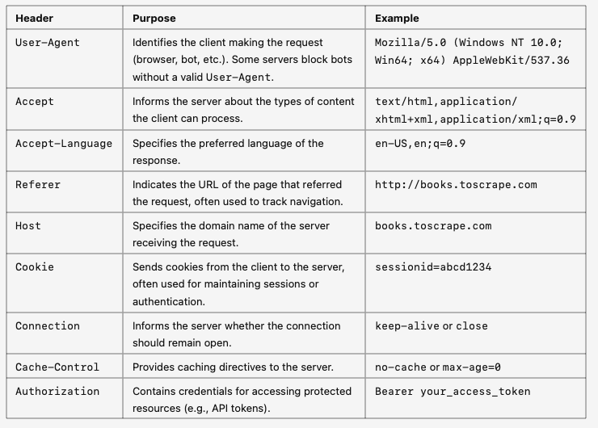

Now let's send a request to the server.

- If the request is successful, a status code of 200 will be returned

```python
response = requests.get(url)
if response.status_code == 200:
    print("Successfully fetched the webpage!")
else:
    print("Failed to fetch the webpage:", response.status_code)

#response.text
```

```
Successfully fetched the webpage!
```

The response includes the html codes in the `.text` attribute.

```python
#response.text
```

The next step is to use BeautifulSoup to parse the response.

```python
soup = BeautifulSoup(response.text, 'html.parser')
soup
```

[output not shown]

[output cut: 956 more lines]

[output not shown]

A simplified example to demonstrate the structure of html.

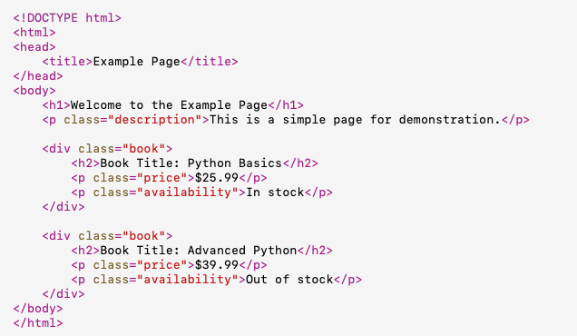

As we can see, an html file is divided into sections by tags, in the form of `<tag_name>...</tag_name>`. Each section is corresponding to a certain part of the web page.

For example:

- There are multiple sections of `<article>...</article>` in the html file.
- Each of those sections is corresponding to the "information block" of a book.

One can inspect the html codes of a webpage by right-clicking on the browser then select "View Page Source".

[figure not shown]

The `.find()` and `.find_all()` methods help us find specific sections of the html file by the name of the tags.

Below, let's find all `<article>...</article>` tags with its "class" attribute being `product_pod`.

- The result is a list of blocks of html codes.

```python
books_list = soup.find_all('article', class_='product_pod')
```

```python
book = books_list[0]
book
```

```
<article class="product_pod">
<div class="image_container">
<a href="catalogue/a-light-in-the-attic_1000/index.html"><img alt="A Light in the Attic" class="thumbnail" src="media/cache/2c/da/2cdad67c44b002e7ead0cc35693c0e8b.jpg"/></a>
</div>
<p class="star-rating Three">
<i class="icon-star"></i>
<i class="icon-star"></i>
<i class="icon-star"></i>
<i class="icon-star"></i>
<i class="icon-star"></i>
</p>
<h3><a href="catalogue/a-light-in-the-attic_1000/index.html" title="A Light in the Attic">A Light in the ...</a></h3>
<div class="product_price">
<p class="price_color">Â£51.77</p>
<p class="instock availability">
<i class="icon-ok"></i>

        In stock

</p>
<form>
<button class="btn btn-primary btn-block" data-loading-text="Adding..." type="submit">Add to basket</button>
</form>
</div>
</article>
```

Let's retrieve the title from this block of html codes corresponding to the first book.

```python
title = book.h3.a['title']
title
```

```
'A Light in the Attic'
```

similarly, we can extract:

- rating of the book
- price
- availability

```python
rating = book.p['class'][1]
```

However, `book.p` will only get the first `<p></p>` tag in this block of code. But the price information is included in the second `<p>` tag.

We can find this `<p>` tag by providing its class attribute.

```python
price_str = book.find('p',class_='price_color').text
price = float(price_str.replace('Â£',''))
price
```

```
51.77
```

```python
ava = book.find('p',class_='instock availability').text.strip()
ava
```

```
'In stock'
```

```python
print(f"'{title}' has a rating of {rating}; priced at {price} GBP, {ava}.")
```

```
'A Light in the Attic' has a rating of Three; priced at 51.77 GBP, In stock.
```

To get information about all books on page 1, we first create empty lists of titles, ratings, prices, and availability.

Then we enumerate each `<article>` tag to populate the lists.

```python
titles = []
ratings = []
prices = []
avails = []

for book in books_list:
    title = book.h3.a['title']
    rating = book.p['class'][1]
    price_str = book.find('p',class_='price_color').text
    price = price_str.replace('Â£','')
    availability = book.find('p',class_='instock availability').text.strip()

    titles.append(title)
    ratings.append(rating)
    prices.append(price)
    avails.append(availability)
```

```python
import pandas as pd
df_books = pd.DataFrame({
    'Title': titles,
    'Rating': ratings,
    'Price': prices,
    'Availability':avails
})
df_books
```

|  | Title | Rating | Price | Availability |
| --- | --- | --- | --- | --- |
| 0 | A Light in the Attic | Three | 51.77 | In stock |
| 1 | Tipping the Velvet | One | 53.74 | In stock |
| 2 | Soumission | One | 50.10 | In stock |
| 3 | Sharp Objects | Four | 47.82 | In stock |
| 4 | Sapiens: A Brief History of Humankind | Five | 54.23 | In stock |
| 5 | The Requiem Red | One | 22.65 | In stock |
| 6 | The Dirty Little Secrets of Getting Your Dream... | Four | 33.34 | In stock |
| 7 | The Coming Woman: A Novel Based on the Life of... | Three | 17.93 | In stock |
| 8 | The Boys in the Boat: Nine Americans and Their... | Four | 22.60 | In stock |
| 9 | The Black Maria | One | 52.15 | In stock |
| 10 | Starving Hearts (Triangular Trade Trilogy, #1) | Two | 13.99 | In stock |
| 11 | Shakespeare's Sonnets | Four | 20.66 | In stock |
| 12 | Set Me Free | Five | 17.46 | In stock |
| 13 | Scott Pilgrim's Precious Little Life (Scott Pi... | Five | 52.29 | In stock |
| 14 | Rip it Up and Start Again | Five | 35.02 | In stock |
| 15 | Our Band Could Be Your Life: Scenes from the A... | Three | 57.25 | In stock |
| 16 | Olio | One | 23.88 | In stock |
| 17 | Mesaerion: The Best Science Fiction Stories 18... | One | 37.59 | In stock |
| 18 | Libertarianism for Beginners | Two | 51.33 | In stock |
| 19 | It's Only the Himalayas | Two | 45.17 | In stock |

We may proceed to page 2, and repeat the whole procedure to get all books on page 2.

Note that we need to provide the url of page 2.

```python
page = 2
url = f"https://books.toscrape.com/catalogue/page-{page}.html"
url
```

```
'https://books.toscrape.com/catalogue/page-2.html'
```

To automate the procedure of scaping all pages (50 pages in total), we can use a for loop to enumerate all pages.

```python
import time
titles = []
prices = []
avails = []
ratings = []

for page in range(1,51):
    url = f"https://books.toscrape.com/catalogue/page-{page}.html"
    response = requests.get(url)

    if response.status_code == 200:
        print(f"Successfully fetched page {page}!")
    else:
        print(f"Failed to fetch page {page}:", response.status_code)
        break

    soup = BeautifulSoup(response.text, 'html.parser')
    books = soup.find_all('article', class_='product_pod')

    for book in books:
        title = book.h3.a['title']
        rating = book.p['class'][1]
        price_str = book.find('p',class_='price_color').text
        price = price_str.replace('Â£','')
        availability = book.find('p',class_='instock availability').text.strip()
        titles.append(title)
        ratings.append(rating)
        prices.append(price)
        avails.append(availability)

    #time.sleep(2)
```

```
Successfully fetched page 1!
Successfully fetched page 2!
Successfully fetched page 3!
Successfully fetched page 4!
Successfully fetched page 5!
Successfully fetched page 6!
Successfully fetched page 7!
Successfully fetched page 8!
Successfully fetched page 9!
Successfully fetched page 10!
Successfully fetched page 11!
Successfully fetched page 12!
Successfully fetched page 13!
Successfully fetched page 14!
Successfully fetched page 15!
Successfully fetched page 16!
Successfully fetched page 17!
Successfully fetched page 18!
Successfully fetched page 19!
Successfully fetched page 20!
Successfully fetched page 21!
Successfully fetched page 22!
Successfully fetched page 23!
Successfully fetched page 24!
Successfully fetched page 25!
Successfully fetched page 26!
Successfully fetched page 27!
Successfully fetched page 28!
Successfully fetched page 29!
Successfully fetched page 30!
Successfully fetched page 31!
Successfully fetched page 32!
Successfully fetched page 33!
Successfully fetched page 34!
Successfully fetched page 35!
Successfully fetched page 36!
Successfully fetched page 37!
Successfully fetched page 38!
Successfully fetched page 39!
Successfully fetched page 40!
Successfully fetched page 41!
Successfully fetched page 42!
Successfully fetched page 43!
Successfully fetched page 44!
Successfully fetched page 45!
Successfully fetched page 46!
Successfully fetched page 47!
Successfully fetched page 48!
Successfully fetched page 49!
Successfully fetched page 50!
```

It is a good practice to create a brief pause between two http requests, so as not to get blocked!

- One may use `time.sleep(2)` to pause for 2 seconds

```python
df_all_books = pd.DataFrame({
    'Title': titles,
    'Rating': ratings,
    'Price': prices,
    'Availability':avails
})
df_all_books
```

|  | Title | Rating | Price | Availability |
| --- | --- | --- | --- | --- |
| 0 | A Light in the Attic | Three | 51.77 | In stock |
| 1 | Tipping the Velvet | One | 53.74 | In stock |
| 2 | Soumission | One | 50.10 | In stock |
| 3 | Sharp Objects | Four | 47.82 | In stock |
| 4 | Sapiens: A Brief History of Humankind | Five | 54.23 | In stock |
| ... | ... | ... | ... | ... |
| 995 | Alice in Wonderland (Alice's Adventures in Won... | One | 55.53 | In stock |
| 996 | Ajin: Demi-Human, Volume 1 (Ajin: Demi-Human #1) | Four | 57.06 | In stock |
| 997 | A Spy's Devotion (The Regency Spies of London #1) | Five | 16.97 | In stock |
| 998 | 1st to Die (Women's Murder Club #1) | One | 53.98 | In stock |
| 999 | 1,000 Places to See Before You Die | Five | 26.08 | In stock |

1000 rows × 4 columns